# 8: Representing Sequences of Words as Data

Michael Jacobs

# Motivation and Overview

## Recap

Last week, we moved from **sparse** to **dense** representations of words

$$\begin{align}
w_{\text{debt}} &= \begin{bmatrix}
0 & 0 & 1 & 0 & 0 & 0 & 0 & 0 & 0 & ...& 0
\end{bmatrix}
\end{align}$$

$$\begin{align}
w_{\text{debt}} &= \begin{bmatrix}
0.63 & 0.14 & 0.02 & -0.58 & ...& -0.66
\end{bmatrix}
\end{align}$$

This came with several advantages:

- Better at capturing the meanings of words
- Allows for “automatic generalisation” (do more with less text)

Can we do the same thing now with **sequences** of words?

## Motivating Problem

**Do protest groups’ demands get replicated in the media?**

**Just Stop Oil activist:**

“

This has sparked millions upon millions of conversations worldwide and I think that if even a tenth of those conversations mentioned new licences for oil and gas, that’s worth it.

”

**How can we test this?**

Data:

- Corpus of approx. 1 million tweets by UK environmental protest groups
- Corpus of approx. 130,000 UK news articles about the environment

**Measurement tasks:**

1. Cluster the tweets to discover the claims
2. Find new instances of claims in the news

[figure not shown]

[figure not shown]

## Mapping sentences into a semantic space

Recall that word embeddings mapped synonymous or **interchangeable** words close together.

What is a meaningful semantic space for **sentences**?

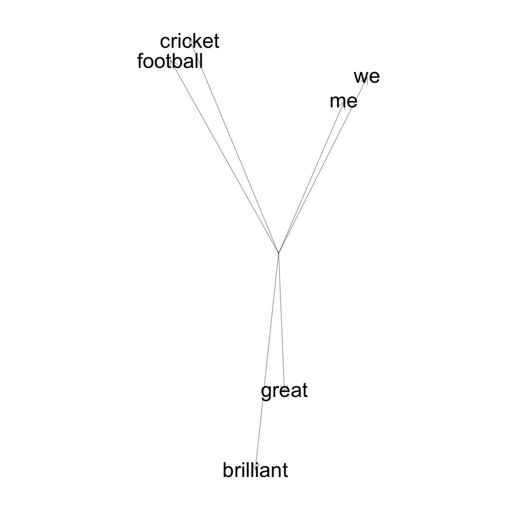

## Mapping sentences into a semantic space

Recall that word embeddings mapped synonymous or **interchangeable** words close together.

What is a meaningful semantic space for **sentences**?

1. Paraphrasings

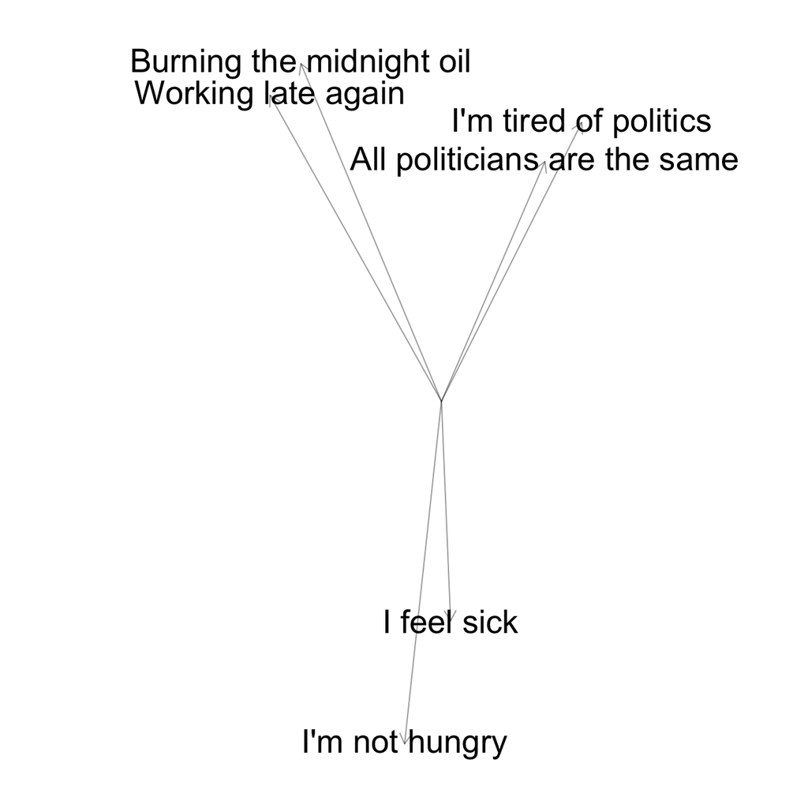

## Mapping sentences into a semantic space

Recall that word embeddings mapped synonymous or **interchangeable** words close together.

What is a meaningful semantic space for **sentences**?

1. Paraphrasings
2. Entailment/contradiction

[figure not shown]

## Mapping sentences into a semantic space

Recall that word embeddings mapped synonymous or **interchangeable** words close together.

What is a meaningful semantic space for **sentences**?

1. Paraphrasings
2. Entailment/contradiction
3. Question-answer relevance

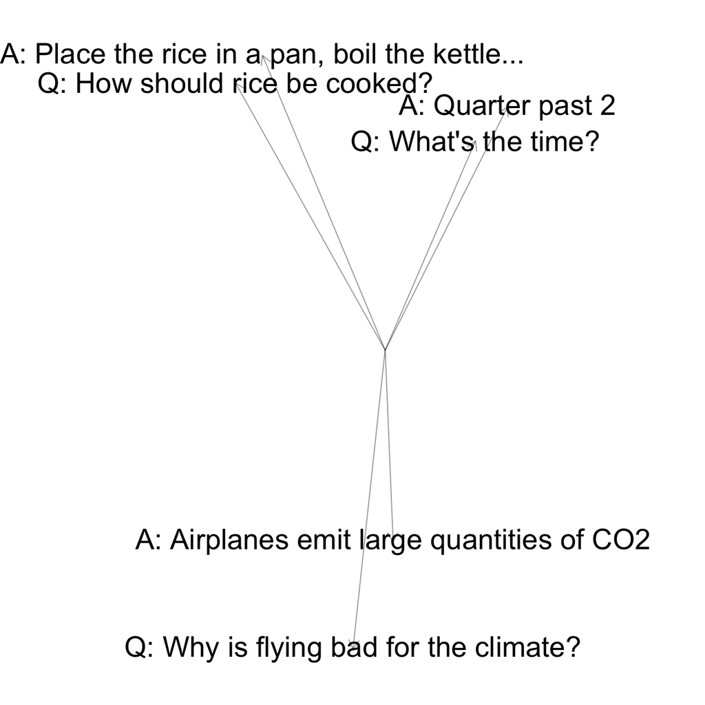

## Running Example

Which of these sentences ought to be clustered together?

A. “The attacker’s late goal won the match for his side.”

B. “The striker’s contribution was crucial to the team’s victory.”

C. “The striker was critical to the success of the team.”

D. “The manager was critical of how the striker played.”

E. “The coach fiercely condemned the striker’s performance.”

## Running Example

Which of these sentences ought to be clustered together?

A. “The attacker’s late goal won the match for his side.”

B. “The striker’s contribution was crucial to the team’s victory.”

C. “The striker was critical to the success of the team.”

D. “The manager was critical of how the striker played.”

E. “The coach fiercely condemned the striker’s performance.”

The ‘correct’ clustering:

- A, B and C all attribute credit to the striker
- D and E both criticise the striker

## Roadmap

**Bag-of-words approaches**

1. Term frequency representation
2. Aggregate word embeddings

**Beyond bag-of-words**

3. Subword tokenisations
4. Contextualised embeddings
5. Sentence embeddings

**Applications**

6. Clustering
7. Information retrieval

# Bag-of-Words Approaches

## Term frequency representation: Recap

Represent each document with a vector of length $V$ (number of words in vocabulary), representing the count of each unique word-type.

```r
library(quanteda)

dfm1 <- sentences %>%
  tokens() %>%
  tokens_wordstem() %>%
  dfm()

dfm1
```

```
Document-feature matrix of: 5 documents, 27 features (67.41% sparse) and 0 docvars.
       features
docs    the attack late goal won match for his side .
  text1   2      1    1    1   1     1   1   1    1 1
  text2   2      0    0    0   0     0   0   0    0 1
  text3   3      0    0    0   0     0   0   0    0 1
  text4   2      0    0    0   0     0   0   0    0 1
  text5   2      0    0    0   0     0   0   0    0 1
[ reached max_nfeat ... 17 more features ]
```

Calculate the cosine similarity of each pair of rows:

```r
cosine_sim_matrices <- function (matA, matB) {
  matA %*% t(matB) / sqrt( rowSums(matA^2) %*% t(rowSums(matB^2)))
}

cosine_sim_matrices(dfm1, dfm1)
```

## Term frequency representation: Running example

The cosine similarity matrix looks like:

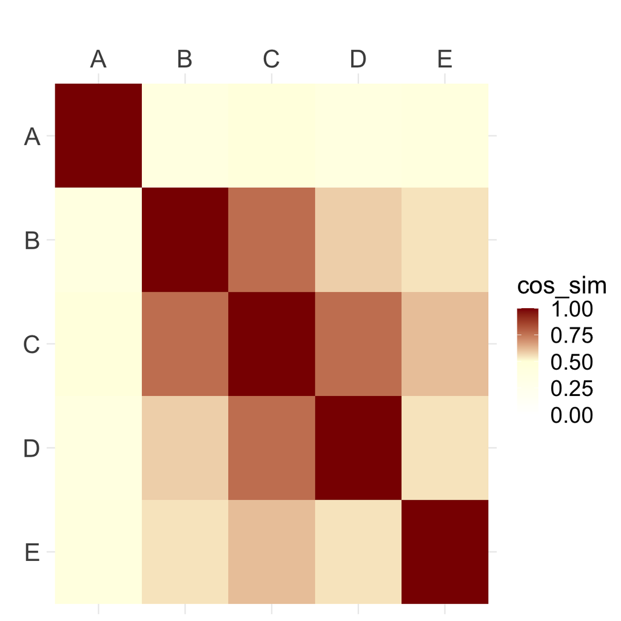

## Aggregated word embeddings: Intro

Word embeddings can help with sentences that use synonymous but different words, e.g.

- “The attacker’s late goal won the match for his side.”
- “The striker’s contribution was crucial to the team’s victory.”

How can we convert the dense representation of each word used…

|  | V1 | V2 | V3 | V4 | V5 | V6 | V7 | ... | V300 |
| --- | --- | --- | --- | --- | --- | --- | --- | --- | --- |
| the | 0.047 | 0.213 | -0.007 | -0.459 | -0.036 | 0.236 | -0.288 | ... | 0.054 |
| attacker | -0.557 | 0.233 | -0.157 | 0.29 | 0.371 | -0.003 | -0.201 | ... | -0.131 |
| late | 0.447 | -0.413 | -0.353 | 0.69 | 0.281 | -0.114 | -0.485 | ... | 0.067 |
| goal | 0.552 | 1.332 | -0.476 | 0.117 | 0.129 | -0.217 | -0.481 | ... | -0.176 |
| ... | ... | ... | ... | ... | ... | ... | ... | ... | ... |
| side | 0.097 | 0.717 | -0.119 | -0.408 | 0.016 | -0.224 | -0.086 | ... | 0.095 |

… into a single dense representation of the whole sentence?

|  | V1 | V2 | V3 | V4 | V5 | V6 | V7 | ... | V300 |
| --- | --- | --- | --- | --- | --- | --- | --- | --- | --- |
| Sentence 1 | 0.007 | 0.045 | 0.019 | -0.003 | 0.1 | 0.105 | 0.1 | ... | -0.017 |

## Aggregated word embeddings: Intuition

We saw last week that arithmetic operations on word vectors produce meaningful results…

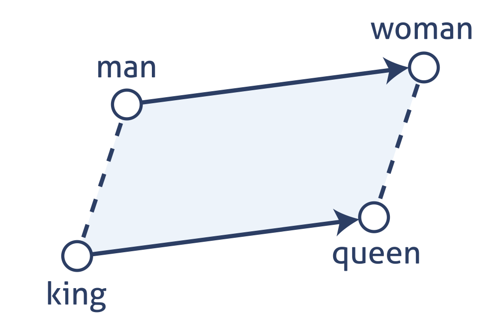

$$\text{vector(king)} - \text{vector(man)} + \text{vector(woman)} \approx \text{vector(queen)}$$

We could just add up all the words in the sentence to represent the whole sentence…

$$\text{vector(The)} + \text{vector(striker)} + \text{vector(was)} + \text{vector(critical)} + ... \approx \text{vector(sentence)}$$

## Aggregated word embeddings: Detail

**Aggregation methods:**

- Weighted sum: $\mathbf{d} = \sum_{i=1}^V \mathbf{w}_i \times f_i$
- Weighted average: $\mathbf{d} = (\sum_{i=1}^V \mathbf{w}_i \times f_i)/(\sum_{i=1}^V f_i)$

Should we sum or average?

**Normalisation:**

- The magnitude of a vector is its Euclidean distance from the origin: $||\mathbf{d}||= \sqrt{\sum_{j=1}^{\mathcal{D}}d_j^2}$
- Normalise a vector by dividing by its magnitude: $\mathbf{d}_{norm} = \frac{\mathbf{d}}{||\mathbf{d}||}$

Summing will represent sentences with more words further from the origin.

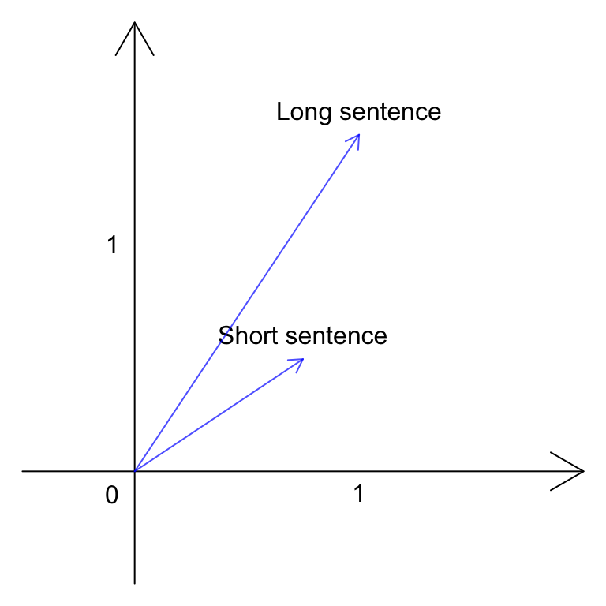

Normalising ensures that every sentence is the same distance from the origin (whether we summed or averaged)

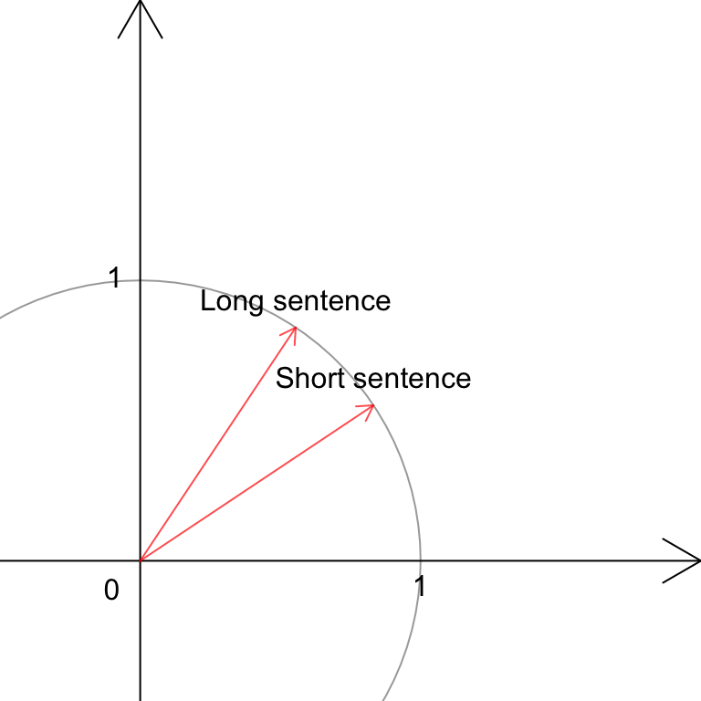

## Aggregated word embeddings: Running example

The cosine similarity matrix looks like:

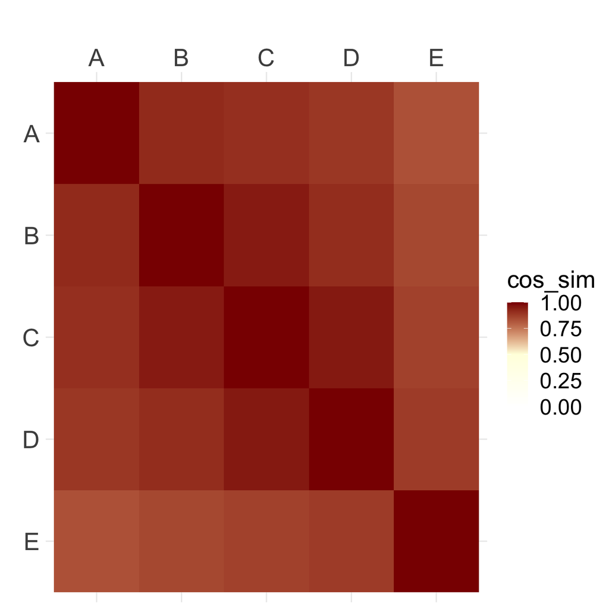

1. “The attacker’s late goal won the match for his side.”
2. “The striker’s contribution was crucial to the team’s victory.”
3. “The striker was critical to the success of the team.”
4. “The manager was critical of how the striker played.”
5. “The coach fiercely condemned the striker’s performance.”

## The Limits of ‘Bag-of-Words’

1. **Rare / Out-of-vocabulary words (OOV)**
   - Some words do not appear frequently enough to learn a good representation of
   - e.g. domain-specific words, unusual prefixes or suffixes, slang, typos
2. **Polysemy:** The meaning of words depends on context, e.g.
   - “The striker was **critical** to the success of the team.”
   - “The manager was **critical** of the striker.”
3. **Sequential dependencies:** The meaning of a sentence changes depending on word order
   - “The striker criticised the manager.”
   - “The manager criticised the striker.

# Moving Beyond Bag-of-Words

## Subword tokenisation: Motivation

**Out of Vocabulary Problem**

- Using GloVe, we can retrieve embeddings for a vocabulary of 400k words.
- Despite this, there will still be out of vocabulary words that we *cannot* represent
- Domain-specific words: “biochemist”, “cryospheric”
- Mispellings: “strker”, “strikerr”
- Unusual suffixes: “solutionise”, “wrongitude”

**Solutions**

- Expand the vocabulary?
  - Computationally intensive, some words are too rare.
- Stemming/lemmatisation?
  - Results in information loss
- Subword tokenisation
  - Break words into meaningful subtokens
  - Exploits information about the internal structure of words

## Subword tokenisation: Detail

Common words are left intact; rarer words are decomposed:

- ‘biologist’ $\rightarrow$ ‘biologist’
- ‘biochemist’ $\rightarrow$ ‘bio’ + ‘##chemist’
- ‘okay’ $\rightarrow$ ‘okay’
- ‘okeydokey’ $\rightarrow$ ‘ok’ + ‘##ey’ + ‘##do’ + ‘##key’
- Learn a representation for subword types, rather than word types
- Representations for rare words can be reconstructed from subword representations
- vector(bio) + vector(##chemist) = vector(biochemist)
- Subword type representations (e.g. ‘##chemist’) can be reused to form representations of other infrequent words
- e.g. astrochemist, electrochemist, photochemist
- Very rare words can be broken down into character representations
- e.g. ‘UCL’ $\rightarrow$ ‘u’ + ‘##c’ + ‘##l’

## Subword tokenisation: Example

**Wordpiece tokeniser**: Common words are left intact; rarer words are decomposed:

- ‘biologist’ $\rightarrow$ ‘biologist’
- ‘biochemist’ $\rightarrow$ ‘bio’ + ‘##chemist’
- ‘okay’ $\rightarrow$ ‘okay’
- ‘okeydokey’ $\rightarrow$ ‘ok’ + ‘##ey’ + ‘##do’ + ‘##key’

By recombining the embeddings of subtokens, we can meaningfully represent OOV words.

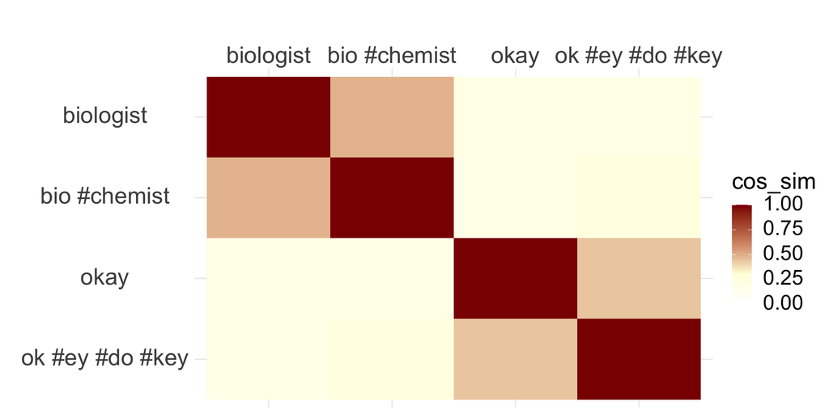

## Contextual Word Embeddings: Intro

Recall sentences (c) and (d):

- “The striker was **critical** to the success of the team.”
- “The manager was **critical** of the striker.”

**Static word embeddings** represent each word-*type* with a vector:

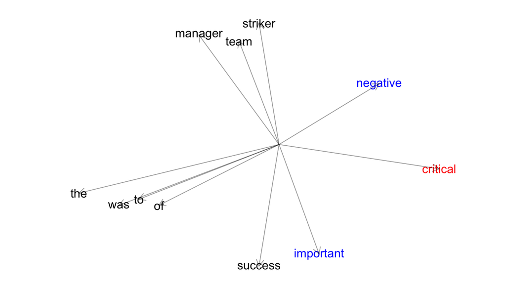

Recall sentences (c) and (d):

- “The<sub>1</sub> striker<sub>1</sub> was<sub>1</sub> **critical<sub>1</sub>** to<sub>1</sub> the<sub>2</sub> success<sub>1</sub> of<sub>1</sub> the<sub>3</sub> team<sub>1</sub>.”
- “The<sub>4</sub> manager<sub>1</sub> was<sub>2</sub> **critical<sub>2</sub>** of<sub>2</sub> the<sub>5</sub> striker<sub>2</sub>.”

**Contextual word embeddings** represent each word-*token* with a vector:

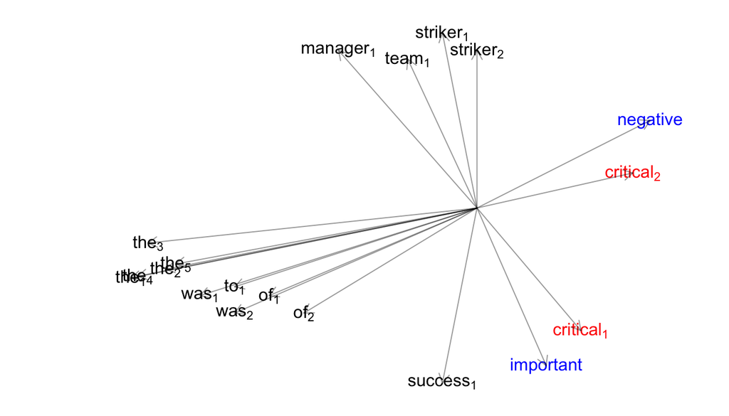

## Contextual Word Embeddings: Intuition

The intuition (Smith 2020):

- “With hindsight, we can now see that by representing word types independent of context, **we were solving a problem that was harder than it needed to be**. Because words mean different things in different contexts, we were requiring that type representations capture all of the possibilities. Moving to **word token vectors simplifies things, asking the word token representation to capture only what a word means in this context**. For the same reasons that the collection of contexts a word type is found in provide clues about its meaning(s), a particular token’s context provides clues about its specific meaning.”
- Use the static word embeddings of tokens surrounding the target word to **update** our representation of the target word in context

## Contextual Word Embeddings: Intuition

With static embeddings, we can retrieve a word’s vector by ‘looking it up’ in a big embedding matrix (e.g. pretrained Glove embeddings)…

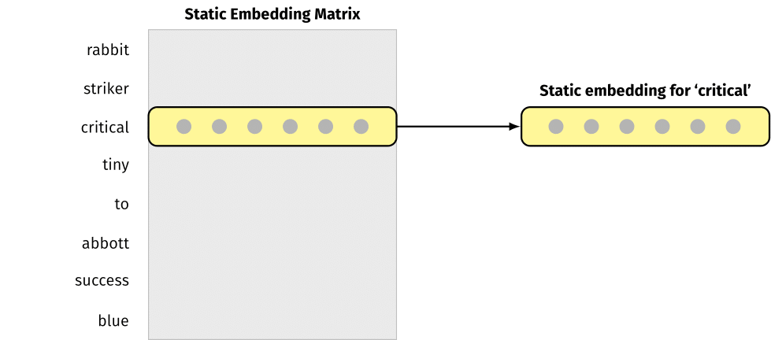

## Contextual Word Embeddings: Intuition

In contrast, a token’s contextual embedding is a function of the static embedding of it’s own word-type **and** the static embeddings of the other words in the sentence…

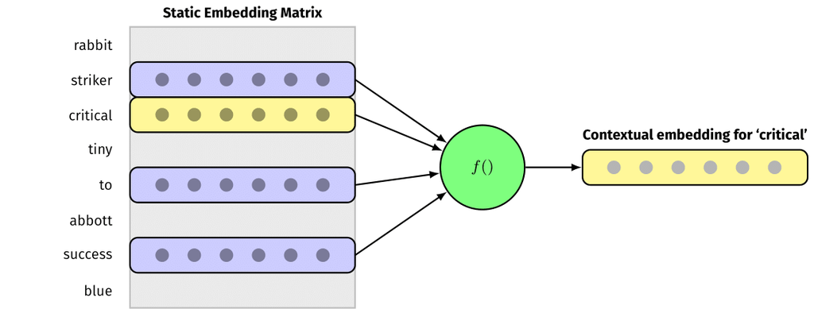

*This is a simplified representation, to be unpacked next week!

## Contextual Word Embeddings: Training

- The function f() is a **neural network** which is a complex non-linear function (more next week).
- Similarly to static embeddings, the function f() can be learned through **masked language modelling**.
  - “I went to the [MASK] and saw a lion.”
  - “What shall we eat for [MASK] ?”

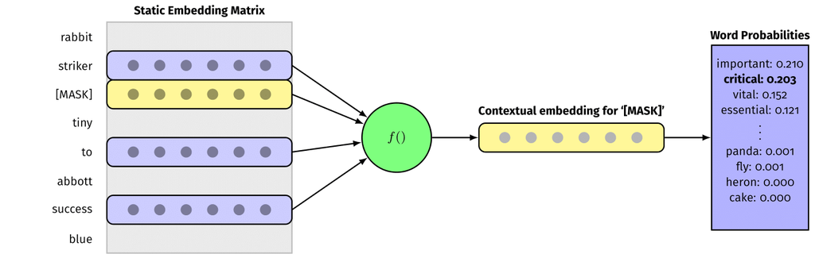

## Contextual Word Embeddings: Training

- The function f() is a **neural network** which is a complex non-linear function (more next week).
- Similarly to static embeddings, the function f() can be learned through **masked language modelling**.
  - “I went to the [MASK] and saw a lion.”
  - “What shall we eat for [MASK] ?”
- Training is very computationally and data intensive.
  - Google: “training … was performed on **16 Cloud TPUs** (64 TPU chips total). Each pretraining took **4 days** to complete.” (Devlin et al. 2018)
- Fortunately, we can make use of pre-trained models, such as **BERT**

## Contextual Word Embeddings: BERT

**BERT: Bidirectional Encoder Representations from Transformers**

- Language model developed by Google in 2018
- Achieved state-of-the-art performance on a wide range of NLP tasks
- Among other things, can produce contextual embeddings

[figure not shown]

## Contextual Word Embeddings: Running example

Distinguishing meanings of ‘critical’

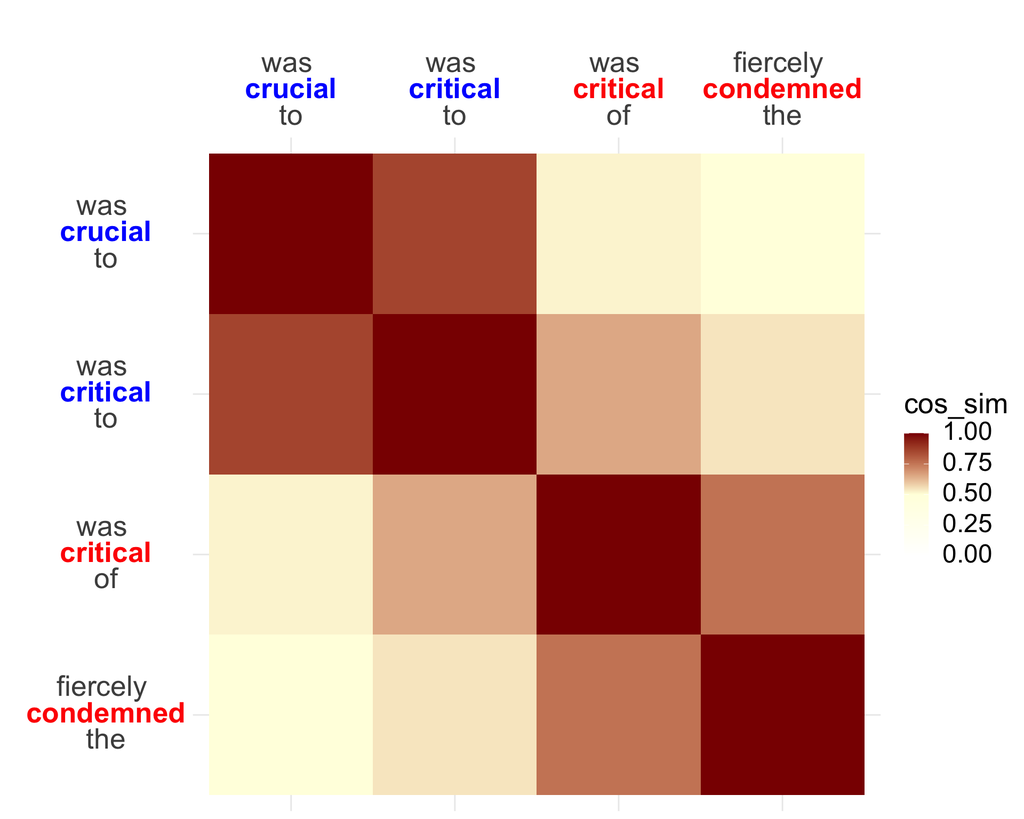

1. “The attacker’s late goal won the match for his side.”
2. “The striker’s contribution was crucial to the team’s victory.”
3. “The striker was critical to the success of the team.”
4. “The manager was critical of how the striker played.”
5. “The coach fiercely condemned the striker’s performance.”

## Contextual Word Embeddings: Applications

**Natural Language Processing Applications:**

1. **Named entity recognition:** Is this token a named entity?
   - “**Apple** released a new iPhone.”
   - “**Apple** crumble is delicious.”
2. **Part-of-speech tagging**: Which tokens are nouns, verbs, etc.?

**Social Science Applications:**

3. **Identifying dehumanising language…**

## Identifying Dehumanising Metaphors (Card et al.)

[figure not shown]

## Identifying Dehumanising Metaphors (Card et al.)

[figure not shown]

“*we measure the extent to which mentions of immigrants in speeches ‘sound like’ a mention of several metaphorical categories that have been previously discussed in the literature on immigration: ‘animals,’ ‘cargo,’ ‘disease,’ ‘flood/tide,’ ‘machines,’ and ‘vermin’*”

## Identifying Dehumanising Metaphors (Card et al.)

**Procedure:**

- **Original sentence:** “… prevent the dumping of undesirable aliens into this country”
- **Masked sentence:** “… prevent the dumping of undesirable [MASK] into this country”
- **‘Cargo’ dictionary:** (things, goods, stuff, …)

**What is the probability that the masked token is from the Cargo dictionary?**

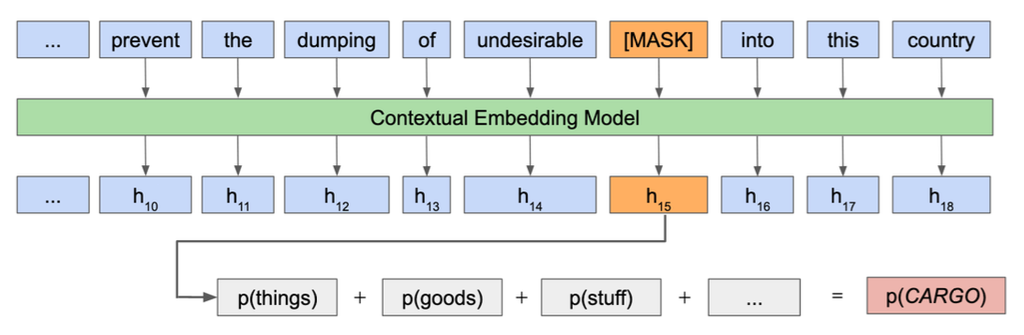

## Identifying Dehumanising Metaphors (Card et al.)

**Example dehumanising metaphors related to animals identified by Card et al**

| Prob. | Masked term | Context |
| --- | --- | --- |
| 0.97 | immigrants | … it would be just as unreasonable to claim that we will not lower american standards by admitting to our country [MASK] that are of lower standards than ours as it is to assert that the breeding of t… |
| 0.66 | aliens | it establishes a positive framework to prevent illegal [MASK] from feeding at the public trough. |

## The story so far

We started with static word embeddings…

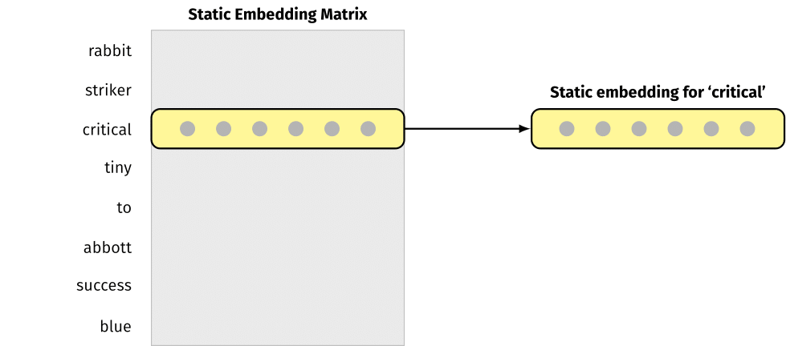

## The story so far

Then we saw how we could aggregate these by summing and normalising…

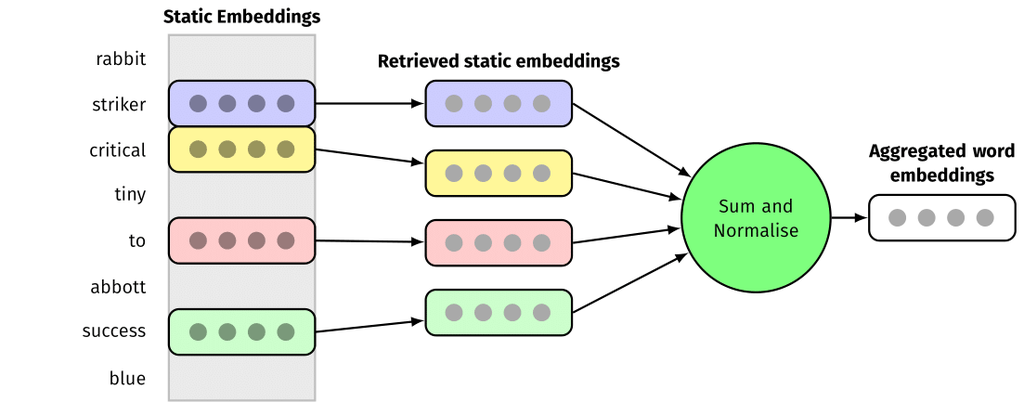

## The story so far

Then we saw how we could use subword tokenisation to capture OOV words…

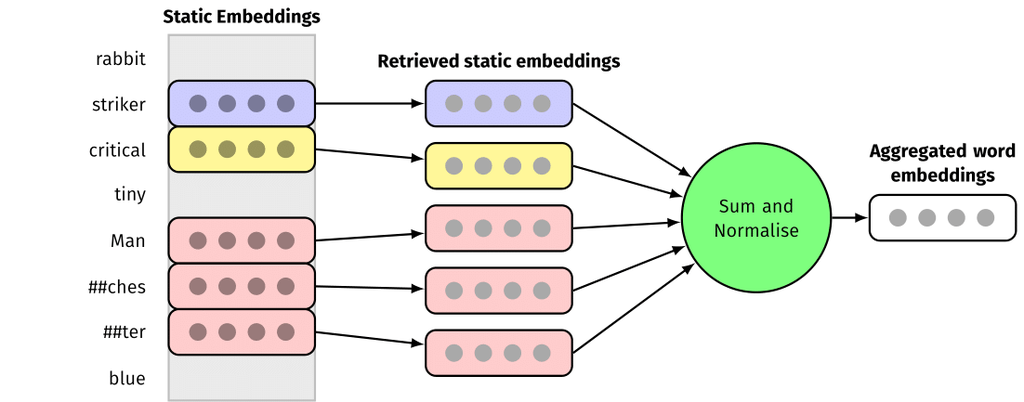

## The story so far

Then we introduced contextual word embeddings, to better capture meanings in context…

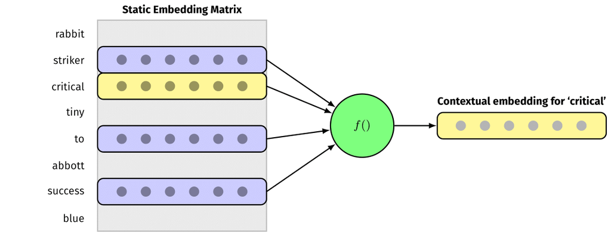

## The story so far

We could now aggregate the contextual embeddings by summing and normalising?

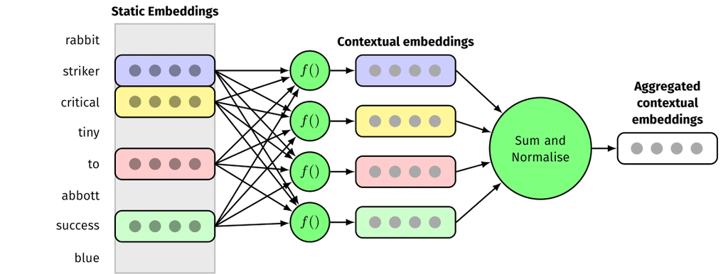

## Sentence-BERT Embeddings: Intro

Sentence-BERT embeddings aggregate contextual embeddings in a way that is optimised for semantic similarity…

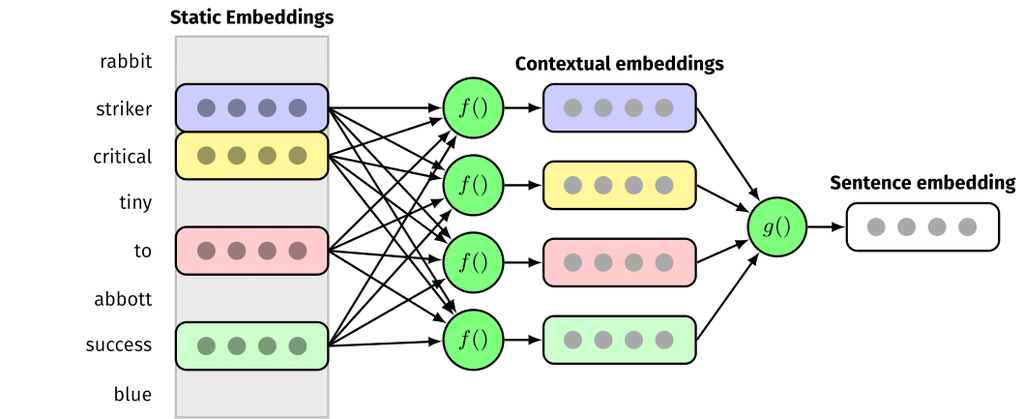

*This is a simplified representation, to be unpacked next week!

## Sentence-BERT Embeddings: Details

What does **g()** do?

1. **Pooling** across tokens (e.g. averaging)
2. Refines representation for sentence similarity tasks using a **feed forward neural network**.

Why not just pool? Why bother with (2)?

- Helps avoid **anisotropy** (observations overly concentrated in one part of the space)

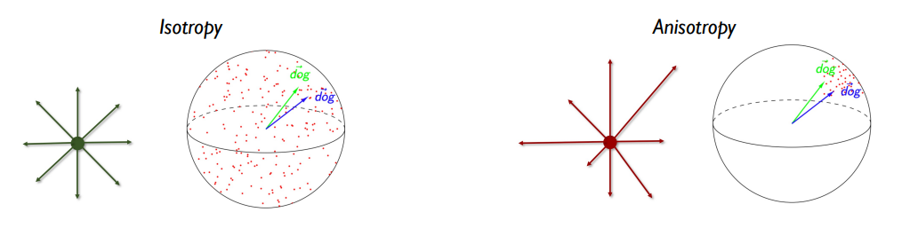

## Sentence-BERT Embeddings: Details

What does **g()** do?

1. **Pooling** across tokens (e.g. averaging)
2. Refines representation for sentence similarity tasks using a **feed forward neural network**.

Why not just pool? Why bother with (2)?

- Helps avoid **anisotropy** (observations overly concentrated in one part of the space)
- Better discrimination between near and distant pairs

Training:

- The f() components are trained with masked language modelling
- The g() component is trained on human annotated and naturally annotated sentence pairs

## Sentence-BERT Embeddings: Training data examples

**Human annotated**: Stanford Natural Language Inference dataset (570k pairs)

| Text | Hypothesis | Label |
| --- | --- | --- |
| A man inspects the uniform of a figure in some East Asian country. | The man is sleeping | Contradiction |
| An older and younger man smiling. | Two men are smiling and laughing at the cats playing on the floor. | Neutral |
| A soccer game with multiple males playing. | Some men are playing a sport. | Entailment |

**Naturally labelled**: WikiAnswers duplicates (77m pairs tagged by WikiAnswers users)

| Question 1 | Question 2 | Label |
| --- | --- | --- |
| What is population of muslims in india? | How many muslims make up indias 1 billion population? | Duplicate |
| How can you tell if you have the flu? | What are signs of the flu? | Duplicate |

## Sentence-BERT Embeddings: Loss function(s)

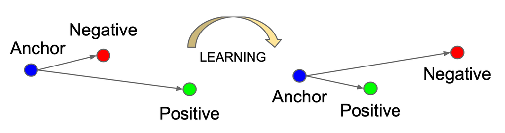

## Sentence-BERT Embeddings: Pre-trained models

There are lots of models to choose from…

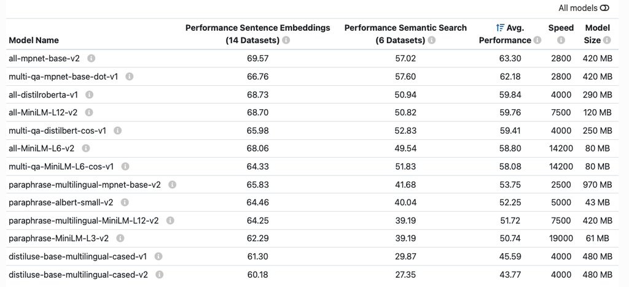

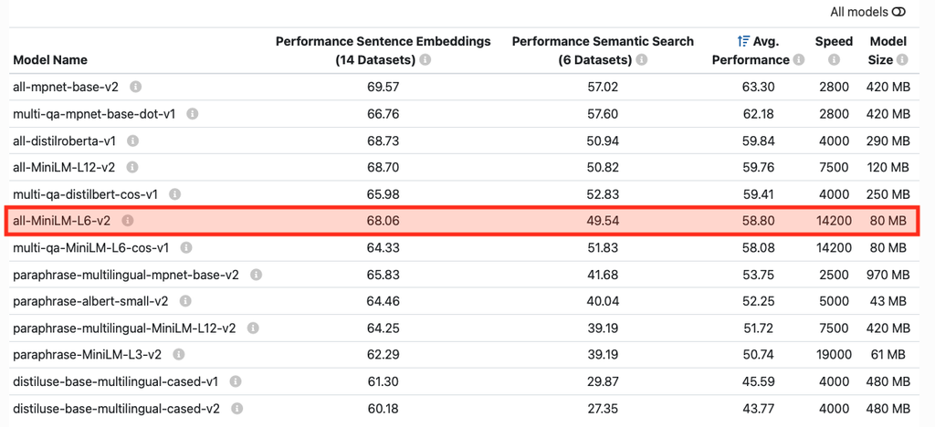